# Reproducible Research: Peer Assessment 1

## Loading and preprocessing the data

Note :Set the working directory

```r
setwd('/home/kushwanth/machinelearning/r_practice/DataScience_Specialization/reproducible research')
activity_data<-read.csv('activity.csv',header = TRUE,sep=',')
activity_data$date<-as.character(activity_data$date)
activity_data$date<-as.Date(activity_data$date,'%Y-%m-%d')
```

## What is mean total number of steps taken per day?

### Calculate the total number of steps taken per day

```r
sum_days<-data.frame()
days<-unique(activity_data$date)

for(index in 1:length(days)){
  sum_days[index,1]<-sum(activity_data$steps[activity_data$date==as.Date(days[index]) & !is.na(activity_data$steps)])
}
sum_days$date<-days
names(sum_days)<-c('sum','date')
```

Above data frame ‘sum_days’ has total number of steps taken per day

### Make a histogram of the total number of steps taken each day

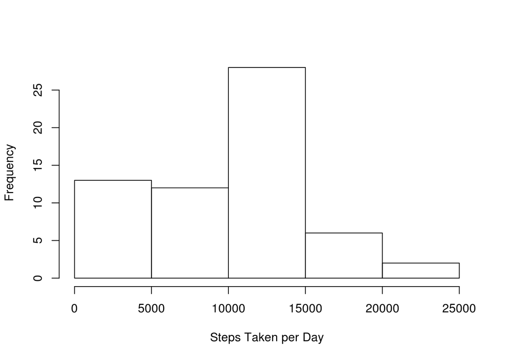

```r
hist(sum_days$sum,xlab='Steps Taken per Day',main='')
```

Above is histogram for Steps taken per day

### The mean and median of the total number of steps taken per day

```r
mean(sum_days$sum)
```

```
## [1] 9354.23
```

```r
median(sum_days$sum)
```

```
## [1] 10395
```

## What is the average daily activity pattern?

### A time series plot of the 5-minute interval (x-axis) and the average number of steps taken, averaged across all days (y-axis)

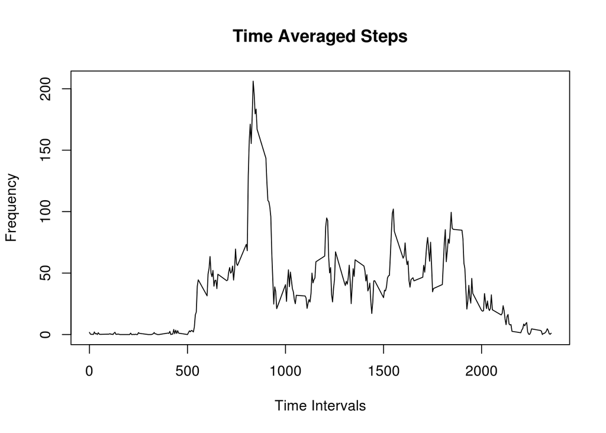

```r
time_intervals<-unique(activity_data$interval)
avg_time_frame<-data.frame()
for(index in 1:length(time_intervals)){
  avg_time_frame[index,1]<-mean(activity_data$steps[activity_data$interval==time_intervals[index] & !is.na(activity_data$steps)])
}
names(avg_time_frame)<-c('avg_steps')
plot(time_intervals,avg_time_frame$avg_steps,type = 'l',xlab = 'Time Intervals',ylab='Frequency',main='Time Averaged Steps')
```

‘avg_time_frame’ is a data frame used to generate the plot

### The 5-minute interval, on average across all the days in the dataset, contains the maximum number of steps :

```r
avg_time_frame$time_intervals<-time_intervals
avg_time_frame$time_intervals[avg_time_frame$avg_steps==max(avg_time_frame$avg_steps)]
```

```
## [1] 835
```

## Imputing missing values

### The total number of missing values in the dataset (i.e. the total number of rows with NAs)

```r
sum(is.na(activity_data$steps)==TRUE)
```

```
## [1] 2304
```

```r
sum(is.na(activity_data$date)==TRUE)
```

```
## [1] 0
```

```r
sum(is.na(activity_data$interval)==TRUE)
```

```
## [1] 0
```

### Strategy for filling in all of the missing values in the dataset : the mean for that 5-minute interval. Create a new dataset that is equal to the original dataset but with the missing data filled in.

```r
na_dates<-unique(activity_data$date[is.na(activity_data$steps)])
imputed_activity_data<-activity_data
for(index in 1:length(na_dates)){
  for(time_index in 1:length(time_intervals)){
    imputed_activity_data$steps[activity_data$date==na_dates[index] & activity_data$interval==time_intervals[time_index]]<-avg_time_frame$avg_steps[time_index]
  }
}
```

### Make a histogram of the total number of steps taken each day and Calculate and report the mean and median total number of steps taken per day.

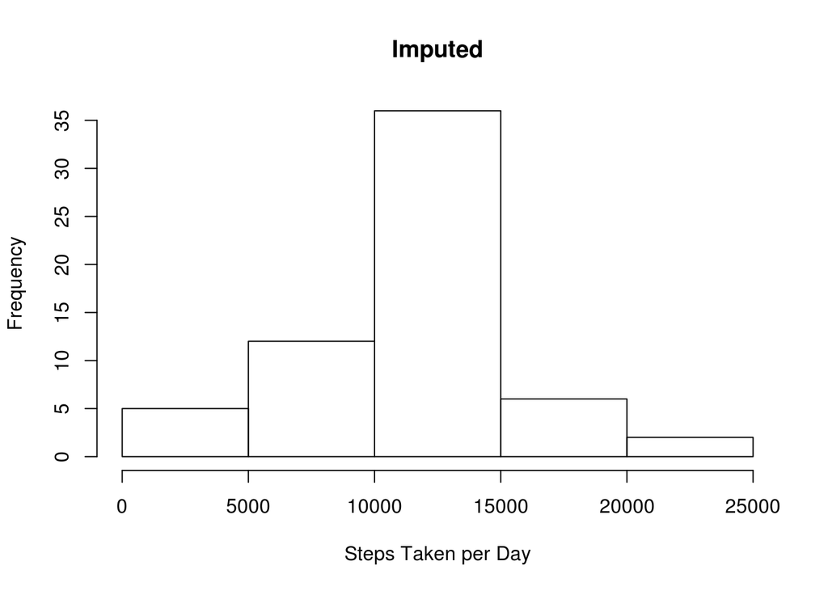

```r
days<-unique(imputed_activity_data$date)
imputed_sum_days<-data.frame()
for(index in 1:length(days)){
  imputed_sum_days[index,1]<-sum(imputed_activity_data$steps[imputed_activity_data$date==as.Date(days[index])])
}
names(imputed_sum_days)<-c('sum')
hist(imputed_sum_days$sum,xlab='Steps Taken per Day',main='Imputed')
```

```r
mean(imputed_sum_days$sum)
```

```
## [1] 10766.19
```

```r
median(imputed_sum_days$sum)
```

```
## [1] 10766.19
```

### Do these values differ from the estimates from the first part of the assignment? What is the impact of imputing missing data on the estimates of the total daily number of steps?

From the above histogram we can identify that the data is more centered biases in data were reduced. i.e. imputing missing data with mean per time interval reduces biases.

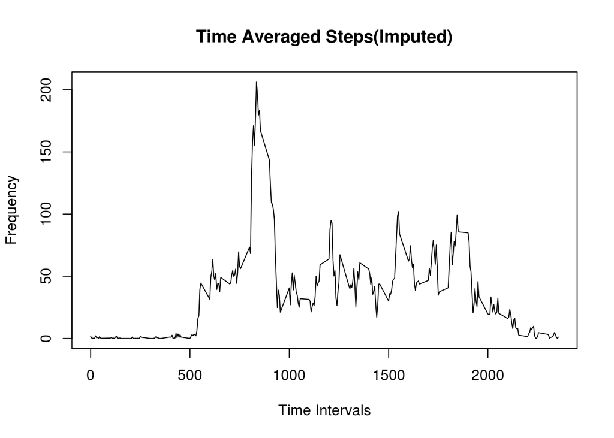

```r
time_intervals<-unique(imputed_activity_data$interval)
imputed_avg_time_frame<-data.frame()
for(index in 1:length(time_intervals)){
  imputed_avg_time_frame[index,1]<-mean(imputed_activity_data$steps[imputed_activity_data$interval==time_intervals[index]])
}
names(imputed_avg_time_frame)<-c('avg_steps')
plot(time_intervals,imputed_avg_time_frame$avg_steps,type = 'l',xlab = 'Time Intervals',ylab='Frequency',main='Time Averaged Steps(Imputed)')
```

## Are there differences in activity patterns between weekdays and weekends?

### A new factor variable in the dataset with two levels – “weekday” and “weekend” indicating whether a given date is a weekday or weekend day is added

```r
for(index in 1:length(imputed_activity_data$date)){
  if(weekdays(imputed_activity_data$date[index])=='Sunday'| weekdays(imputed_activity_data$date[index])=='Saturday')
  {
    imputed_activity_data$day_type[index]<-'weekend'
  }
  else
  {
    imputed_activity_data$day_type[index]<-'weekday'
  }
}
```

### Make a panel plot containing a time series plot (i.e. type = “l”) of the 5-minute interval (x-axis) and the average number of steps taken, averaged across all weekday days or weekend days (y-axis). See the README file in the GitHub repository to see an example of what this plot should look like using simulated data.avg_time_frame

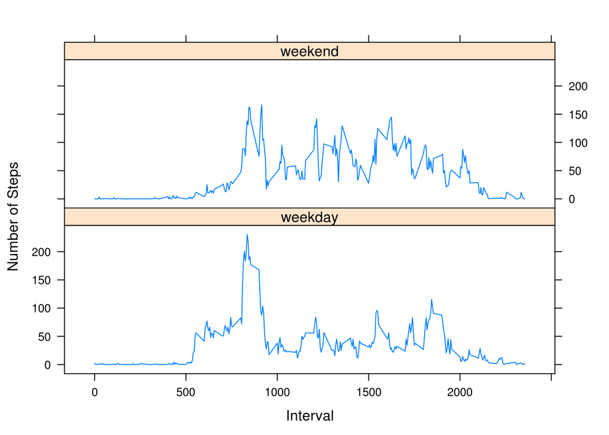

```r
weekday_imputed_avg_time_frame<-data.frame()
weekend_imputed_avg_time_frame<-data.frame()
for(index in 1:length(time_intervals))
{
  weekday_imputed_avg_time_frame[index,1]<-mean(imputed_activity_data$steps[imputed_activity_data$day_type=='weekday' & imputed_activity_data$interval==time_intervals[index]])
  weekday_imputed_avg_time_frame[index,2]<-time_intervals[index]
  weekday_imputed_avg_time_frame[index,3]<-'weekday'
  weekend_imputed_avg_time_frame[index,1]<-mean(imputed_activity_data$steps[imputed_activity_data$day_type=='weekend' & imputed_activity_data$interval==time_intervals[index]])
  weekend_imputed_avg_time_frame[index,2]<-time_intervals[index]
  weekend_imputed_avg_time_frame[index,3]<-'weekend'
}
week_imputed_avg_time_frame<-rbind(weekday_imputed_avg_time_frame,weekend_imputed_avg_time_frame)
rm(weekend_imputed_avg_time_frame,weekday_imputed_avg_time_frame)
names(week_imputed_avg_time_frame)<-c('step_avg','interval','day_type')
library(lattice)
xyplot(week_imputed_avg_time_frame$step_avg~week_imputed_avg_time_frame$interval|factor(week_imputed_avg_time_frame$day_type),
       type='l',layout=c(1,2),xlab='Interval',ylab='Number of Steps',main='')
```